# Explore Red Wine Data by Huda Rezq

## Quality vs Alcohol

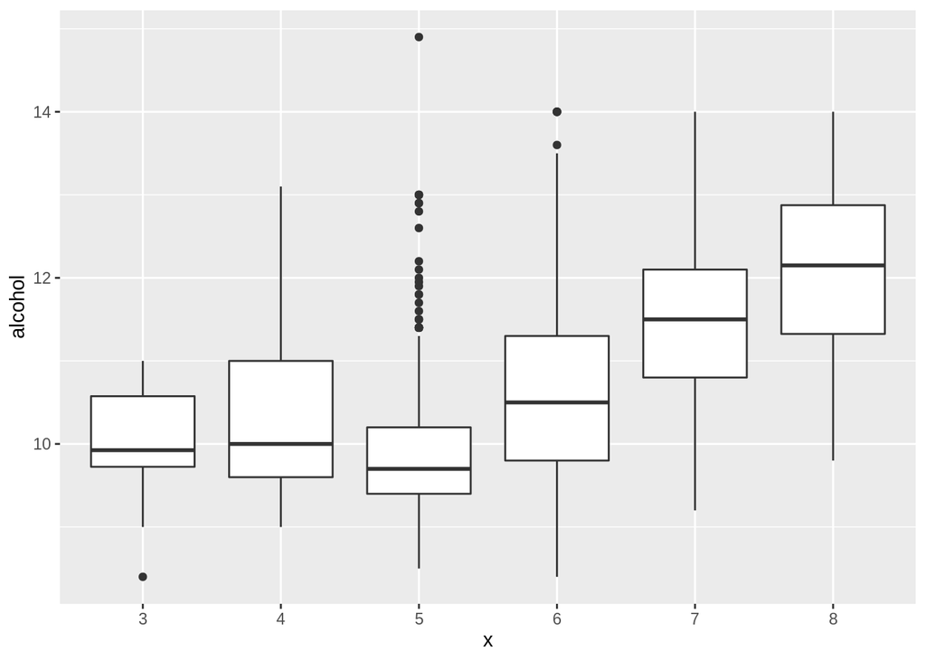

The higher the quality, the higher the alcohol.

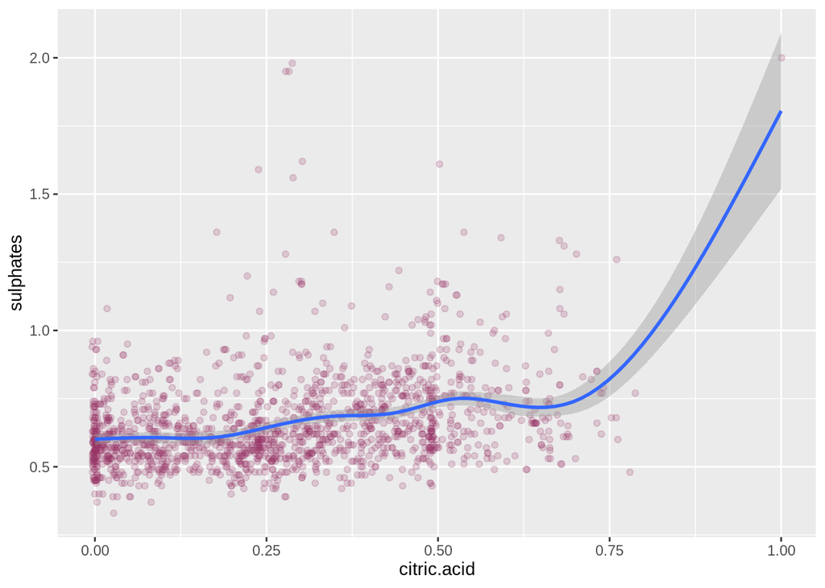

As citric acid level increases, sulphates level tend to increase as well.

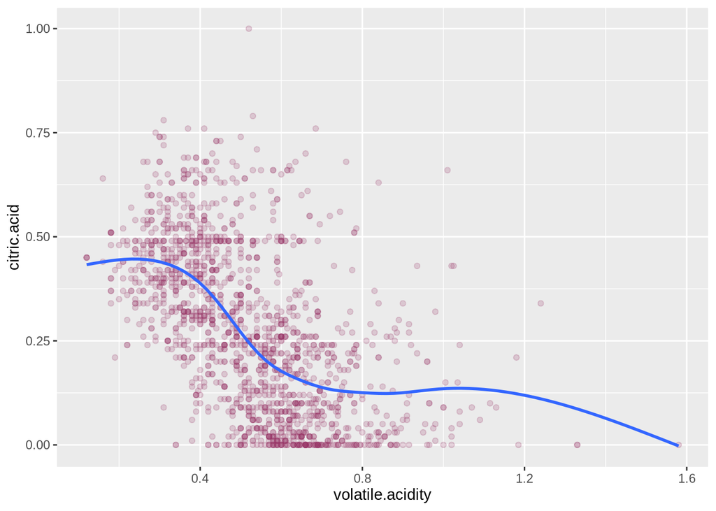

There’s an interesting negative correlation between citric and volatile acid that can be clearly shown using geom_smooth function.

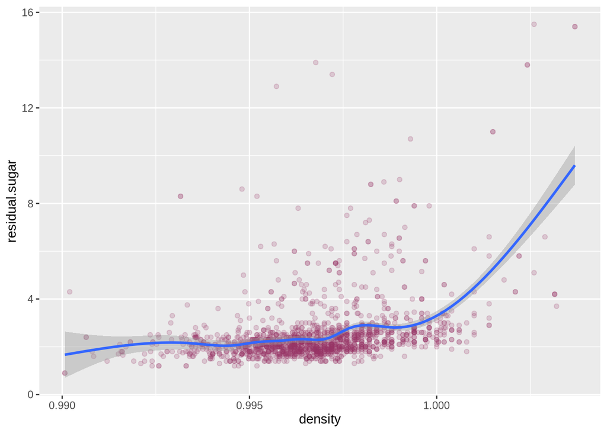

As density increases, residual sugar amount increases as well. Geom_smooth helped in showing the positive correlation.

# Bivariate Analysis

> **Tip**: As before, summarize what you found in your bivariate explorations here. Use the questions below to guide your discussion.

### Talk about some of the relationships you observed in this part of the investigation. How did the feature(s) of interest vary with other features in the dataset?

There are a few attributes exhibit some trends that look promising to be used to predict quality.

- Quality is positively correlated with citric acid, sulphates, and alcohol.
- Quality increases is negatively correlated with volatile acidity, chlorides, density, and pH.

### Did you observe any interesting relationships between the other features (not the main feature(s) of interest)?

Fixed acidity and citric acid are positively correlated because the fixed acidity includes citric acid. * Total sulfur dioxide and free sulfur dioxide are positively correlated because total sulfur dioxide includes free sulfur dioxide. * Fixed acidity and pH are negatively correlated because higher concentration of fixed acidity makes the wine more acidic, therefore the wine has a lower pH. * Citric acid and pH are negatively correlated because higher concentration of citric acid, which is non-volatile, makes the wine more acidic, therefore the wine has a lower pH. * Density and alcohol are negatively correlated because alcohol has a lower density than water, therefore wines that contain more alcohol have a lower density. * Density and fixed acidity are positively correlated because the main fixed acids in wine, tartaric acid, has a higher density than water, therefore wines that contain more tartaric acid have a higher density.

### What was the strongest relationship you found?

The quality of the wine is positivley and highly correlated with alcohol. Moreover, alcohol correlates very highly with the pH levels of the wine. On the other hand, the citric acid levels of the wine correlates highly and negatively with volatile acidity levels which in return correlates with wine quality as well.

# Multivariate Plots Section

## Plot I

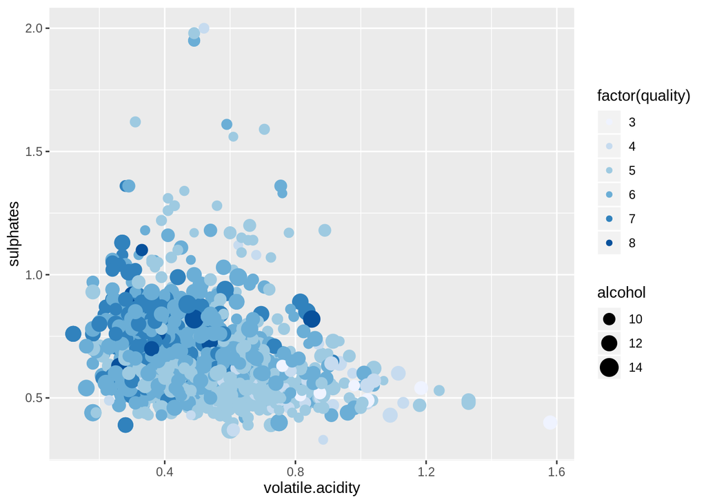

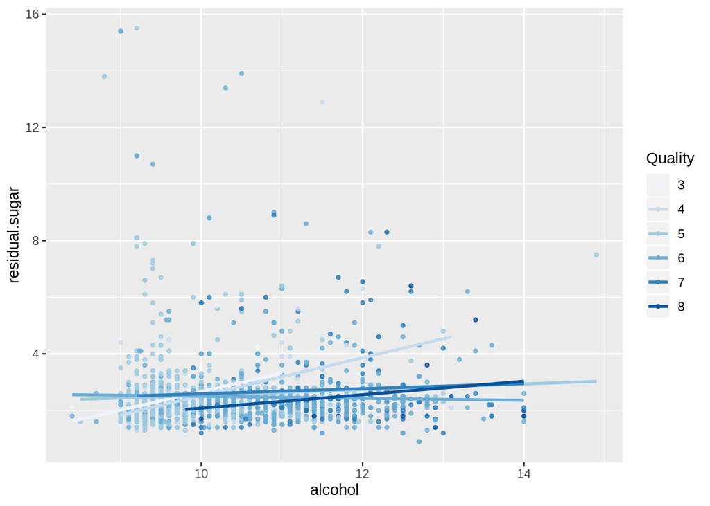

It looks like the higher quality red wines tend to be concentrated in the top left of the plot. This tends to be where the higher alcohol content (larger dots) are concentrated as well.

## Plot II

Let’s try summarizing quality using a contour plot of alcohol and sulphate content:

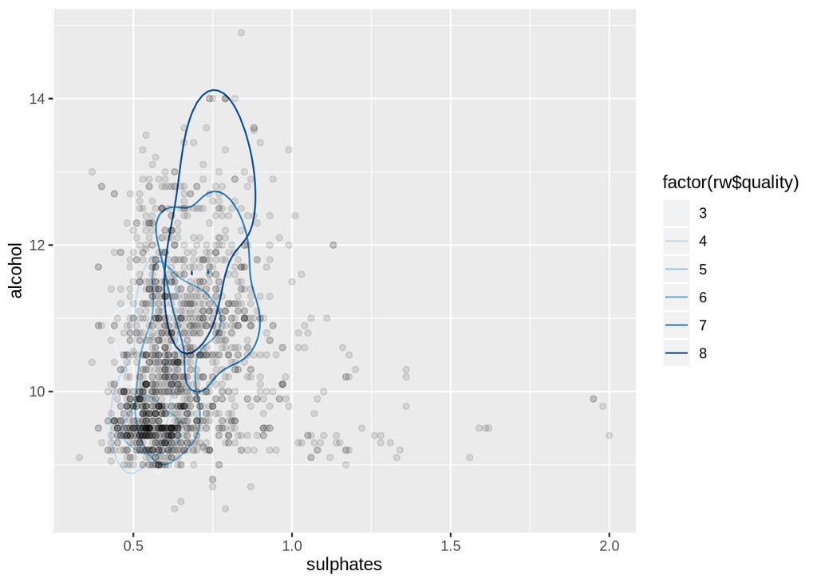

### OPTIONAL: Did you create any models with your dataset? Discuss the strengths and limitations of your model.

# Final Plots

## Plot I

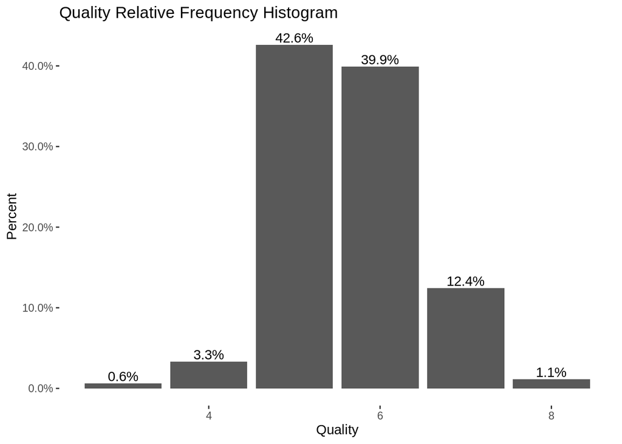

> The possible quality values are ranging from 0 to 10, however, all red wines in the dataset have quality values between 3 and 8. There is no any really bad wine with quality below 3 or any really good wine with quality above 8. Also, most of the red wines have quality 5 or 6, which make the dataset not well balanced.

> The strongest correlation coefficient was found between alcohol and quality. Now let’s look at the alcohol content by red wine quality using a density plot function:

## Plot two

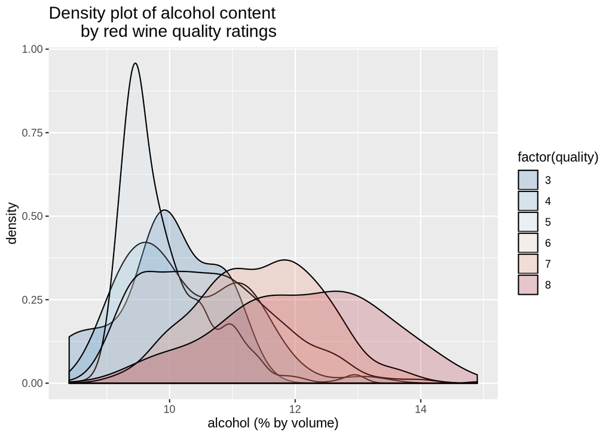

Clearly we see that the density plots for higher quality red wines (as indicated by the red plots) are right shifted, meaning they have a comparatively high alcohol content, compared to the lower quality red wines. However, the main anomoly to this trend appears to be red wines having a quality ranking of 5.

# Plot three

- We can visualize the relationships betwen these two variables, along with alcohol content and red wine quality using a scatter plot:

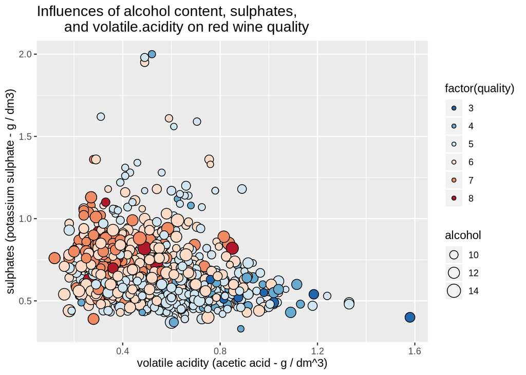

## Plot four

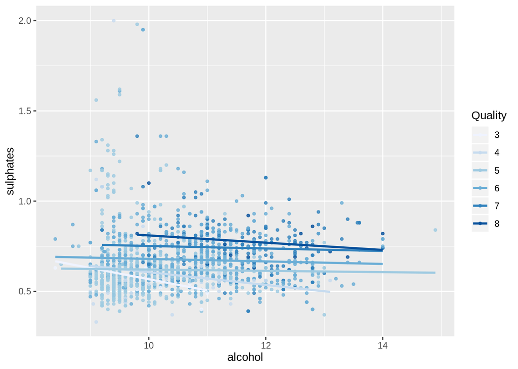

# Reflection

The above analysis considered the relationship of a number of red wine attributes with the quality rankings of different wines. Melting the dataframe and using facet grids was really helpful for visualizing the distribution of each of the parameters with the use of boxplots and histograms. Most of the parameters were found to be normally distributed while citirc acid, free sulfur dioxide and total sulfur dioxide and alcohol had more of a lognormal distribution.

Using the insights from correlation coefficients provided by the paired plots, it was interesting exploring quality using density plots with a different color for each quality. Once I had this plotted it was interesting to build up the multivariate scatter plots to visualize the relationship of different variables with quality by also varying the point size, using density plots on the x and y axis, and also using density plots.

A next step would be to develop a statistical model to predict red wine quality based on the data in this dataset.